# Lab Five: Wide and Deep Networks

### By Xiangying Chang, Fang Qi, Rui Lin, Shimeng Yuan

# 1.Preparation

## 1.1 Business Understanding

This dataset has over 370,000 instances of used cars and 20 features, including both categorical and numerical features. It matches the Lab requirement and is free to download at kaggle.com.

Driving is a common way to go out in the United States. US vehicle registration data shows that about 276.1 million vehicles were registered in 2018. The United States is one of the largest automobile markets around the world. In the overall US automotive market, the used car market is an important component. According to the statistics from statista.com released in March 2018, sales of new car dropped to 17.1 million vehicles while sales of used car climbed to an all-time high of 42.7 million vehicles in 2017. In the used car market, price is always a significant issue for both sellers and buyers because sellers want to sell a car at the highest price while buyers want to buy an ideal used car at the lowest price.

So we decided to use 8 different kinds of price range to help us to explore the features relationship.
(0: price < $\$$2000; 1: $\$$2000 < price < $\$$5000; 2: $\$$5000 < price < $\$$10000; 3: $\$$10000 < price < $\$$15000; 4: $\$$15000 < price < $\$$20000; 5: $\$$20000 < price < $\$$25000; 6: $\$$25000 < price < $\$$30000; 7: $\$$30000 < price. )

Through visualizing the features, exploring the features relationship, and other methods, we are able to help sellers and buyers to understand the most significant issues leading to the price range of used car. From the analyzing, the sellers could have an idea what kind of price range they can sell at to maximize their benefits, and the buyers could have an idea what kind of the best used car they can buy under their budgets. The end goal of analyzing a dataset like this would be to help sellers and buyers to predict the price range of car based on the different features of car they have.

We are trying to used the past data to analysis what features will affect the price range most, or which decided the car's price range. And we split our data to test whether the factors we found are really affect a used car's price range when we do prediction. If the algorithm is learning properly, we expect the difference between the actual price and the predicted price range as small as possible. This may help some websites which are helping value the used cars' price range, like Kelly Blue Book, to predict the cars' value range more accuray. That's what we are trying to achieve in this Lab.

## 1.2 Class Variables

### 1.2.1 Preparing the data (Get clean data can be used to predict)

```python
import pandas as pd
import numpy as np
import seaborn as sns
import matplotlib as mpl
import matplotlib.pyplot as plt
import missingno as mn
import warnings
warnings.filterwarnings("ignore")
%matplotlib inline

df = pd.read_csv('autos.csv',encoding='latin_1')

df.head() # Show the name of each column
```

|  | dateCrawled | name | seller | offerType | price | abtest | vehicleType | yearOfRegistration | gearbox | powerPS | model | kilometer | monthOfRegistration | fuelType | brand | notRepairedDamage | dateCreated | nrOfPictures | postalCode | lastSeen |
| --- | --- | --- | --- | --- | --- | --- | --- | --- | --- | --- | --- | --- | --- | --- | --- | --- | --- | --- | --- | --- |
| 0 | 2016-03-24 11:52:17 | Golf_3_1.6 | privat | Angebot | 480 | test | NaN | 1993 | manuell | 0 | golf | 150000 | 0 | benzin | volkswagen | NaN | 2016-03-24 00:00:00 | 0 | 70435 | 2016-04-07 03:16:57 |
| 1 | 2016-03-24 10:58:45 | A5_Sportback_2.7_Tdi | privat | Angebot | 18300 | test | coupe | 2011 | manuell | 190 | NaN | 125000 | 5 | diesel | audi | ja | 2016-03-24 00:00:00 | 0 | 66954 | 2016-04-07 01:46:50 |
| 2 | 2016-03-14 12:52:21 | Jeep_Grand_Cherokee_"Overland" | privat | Angebot | 9800 | test | suv | 2004 | automatik | 163 | grand | 125000 | 8 | diesel | jeep | NaN | 2016-03-14 00:00:00 | 0 | 90480 | 2016-04-05 12:47:46 |
| 3 | 2016-03-17 16:54:04 | GOLF_4_1_4__3TÜRER | privat | Angebot | 1500 | test | kleinwagen | 2001 | manuell | 75 | golf | 150000 | 6 | benzin | volkswagen | nein | 2016-03-17 00:00:00 | 0 | 91074 | 2016-03-17 17:40:17 |
| 4 | 2016-03-31 17:25:20 | Skoda_Fabia_1.4_TDI_PD_Classic | privat | Angebot | 3600 | test | kleinwagen | 2008 | manuell | 69 | fabia | 90000 | 7 | diesel | skoda | nein | 2016-03-31 00:00:00 | 0 | 60437 | 2016-04-06 10:17:21 |

```python
df.info() # Based information about each column type
```

```
<class 'pandas.core.frame.DataFrame'>
RangeIndex: 371528 entries, 0 to 371527
Data columns (total 20 columns):
dateCrawled            371528 non-null object
name                   371528 non-null object
seller                 371528 non-null object
offerType              371528 non-null object
price                  371528 non-null int64
abtest                 371528 non-null object
vehicleType            333659 non-null object
yearOfRegistration     371528 non-null int64
gearbox                351319 non-null object
powerPS                371528 non-null int64
model                  351044 non-null object
kilometer              371528 non-null int64
monthOfRegistration    371528 non-null int64
fuelType               338142 non-null object
brand                  371528 non-null object
notRepairedDamage      299468 non-null object
dateCreated            371528 non-null object
nrOfPictures           371528 non-null int64
postalCode             371528 non-null int64
lastSeen               371528 non-null object
dtypes: int64(7), object(13)
memory usage: 56.7+ MB
```

```python
df.describe()
```

|  | price | yearOfRegistration | powerPS | kilometer | monthOfRegistration | nrOfPictures | postalCode |
| --- | --- | --- | --- | --- | --- | --- | --- |
| count | 3.715280e+05 | 371528.000000 | 371528.000000 | 371528.000000 | 371528.000000 | 371528.0 | 371528.00000 |
| mean | 1.729514e+04 | 2004.577997 | 115.549477 | 125618.688228 | 5.734445 | 0.0 | 50820.66764 |
| std | 3.587954e+06 | 92.866598 | 192.139578 | 40112.337051 | 3.712412 | 0.0 | 25799.08247 |
| min | 0.000000e+00 | 1000.000000 | 0.000000 | 5000.000000 | 0.000000 | 0.0 | 1067.00000 |
| 25% | 1.150000e+03 | 1999.000000 | 70.000000 | 125000.000000 | 3.000000 | 0.0 | 30459.00000 |
| 50% | 2.950000e+03 | 2003.000000 | 105.000000 | 150000.000000 | 6.000000 | 0.0 | 49610.00000 |
| 75% | 7.200000e+03 | 2008.000000 | 150.000000 | 150000.000000 | 9.000000 | 0.0 | 71546.00000 |
| max | 2.147484e+09 | 9999.000000 | 20000.000000 | 150000.000000 | 12.000000 | 0.0 | 99998.00000 |

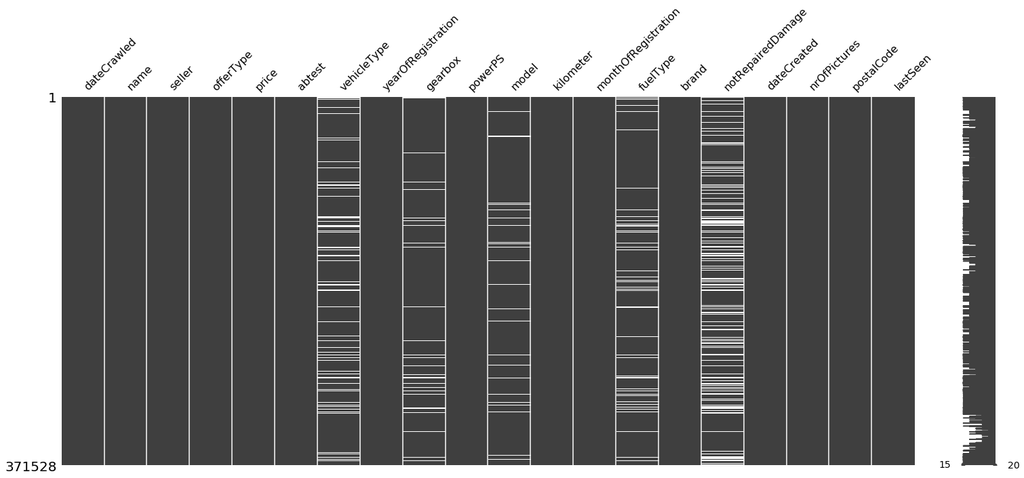

```python
mn.matrix(df.sort_values(by=["name",]))
```

In order to complete the cleaning process, we need to sum up the number of thr missing value under each column.

```python
print(df.isnull().sum())
```

```
dateCrawled                0
name                       0
seller                     0
offerType                  0
price                      0
abtest                     0
vehicleType            37869
yearOfRegistration         0
gearbox                20209
powerPS                    0
model                  20484
kilometer                  0
monthOfRegistration        0
fuelType               33386
brand                      0
notRepairedDamage      72060
dateCreated                0
nrOfPictures               0
postalCode                 0
lastSeen                   0
dtype: int64
```

According to the results, we get some missing numbers for 'vehicleType', 'gearbox', 'model', 'fuelType', 'notRepairedDamage'. Then we need to cleaning these missing values for these features. What we need is to predict the price range of used cars, we think 'vehicleType', 'gearbox', 'model', 'fuelType' are the most associated with 'price', and those missing data for our view, we think they are most likely to be the loss of information, not mistakes, so we decide to drop these null values.

```python
df_notnull = df[(df['vehicleType'].notnull()) & (df['gearbox'].notnull()) & (df['model'].notnull())
                     & (df['fuelType'].notnull())]
df_notnull.info()
```

```
<class 'pandas.core.frame.DataFrame'>
Int64Index: 299864 entries, 2 to 371527
Data columns (total 20 columns):
dateCrawled            299864 non-null object
name                   299864 non-null object
seller                 299864 non-null object
offerType              299864 non-null object
price                  299864 non-null int64
abtest                 299864 non-null object
vehicleType            299864 non-null object
yearOfRegistration     299864 non-null int64
gearbox                299864 non-null object
powerPS                299864 non-null int64
model                  299864 non-null object
kilometer              299864 non-null int64
monthOfRegistration    299864 non-null int64
fuelType               299864 non-null object
brand                  299864 non-null object
notRepairedDamage      260956 non-null object
dateCreated            299864 non-null object
nrOfPictures           299864 non-null int64
postalCode             299864 non-null int64
lastSeen               299864 non-null object
dtypes: int64(7), object(13)
memory usage: 48.0+ MB
```

Now, besides feature:'notRepairedDamage', there is not any other missing data for other features. Set the null field in notRepairedDamage to "not declare".

```python
df_notnull['notRepairedDamage'].fillna(value='not declare', inplace=True)
df_notnull.info()
```

```
<class 'pandas.core.frame.DataFrame'>
Int64Index: 299864 entries, 2 to 371527
Data columns (total 20 columns):
dateCrawled            299864 non-null object
name                   299864 non-null object
seller                 299864 non-null object
offerType              299864 non-null object
price                  299864 non-null int64
abtest                 299864 non-null object
vehicleType            299864 non-null object
yearOfRegistration     299864 non-null int64
gearbox                299864 non-null object
powerPS                299864 non-null int64
model                  299864 non-null object
kilometer              299864 non-null int64
monthOfRegistration    299864 non-null int64
fuelType               299864 non-null object
brand                  299864 non-null object
notRepairedDamage      299864 non-null object
dateCreated            299864 non-null object
nrOfPictures           299864 non-null int64
postalCode             299864 non-null int64
lastSeen               299864 non-null object
dtypes: int64(7), object(13)
memory usage: 48.0+ MB
```

We find that there is no empty and missing data, then we think duplicate data here for used car is more likely be mistaken, because it is less possibe that the cars have all same features, so we decide to drop duplicate data.

```python
df_dropduplicates = df_notnull.drop_duplicates(['dateCrawled',])
df_dropduplicates.info()
```

```
<class 'pandas.core.frame.DataFrame'>
Int64Index: 239081 entries, 2 to 371527
Data columns (total 20 columns):
dateCrawled            239081 non-null object
name                   239081 non-null object
seller                 239081 non-null object
offerType              239081 non-null object
price                  239081 non-null int64
abtest                 239081 non-null object
vehicleType            239081 non-null object
yearOfRegistration     239081 non-null int64
gearbox                239081 non-null object
powerPS                239081 non-null int64
model                  239081 non-null object
kilometer              239081 non-null int64
monthOfRegistration    239081 non-null int64
fuelType               239081 non-null object
brand                  239081 non-null object
notRepairedDamage      239081 non-null object
dateCreated            239081 non-null object
nrOfPictures           239081 non-null int64
postalCode             239081 non-null int64
lastSeen               239081 non-null object
dtypes: int64(7), object(13)
memory usage: 38.3+ MB
```

No matter the null values or the duplicate data, we think these quality issues exist are because of the manual input error, so we optimized the data through methods showed above.

###### #

After drop duplicate data, we find some features are not very associated with price, so we decide to delete some features. There are few strange features and values, in order to cleaning the data, we are going to inspect several features to show why we remove them, and the other undesired columns are removed for same purpose.

```python
print(df_dropduplicates['nrOfPictures'].sum()) # From this we need to delete nrOfPictures
print('=======================================')
print(df_dropduplicates.groupby('seller').size()) # From this we need to delete seller
print('=======================================')
print(df_dropduplicates.groupby('offerType').size())
print('=======================================')
print(df_dropduplicates.groupby('abtest').size())
print('=======================================')


# drop these features showed above and few others which I don't need under same purpose
df_new = df_dropduplicates.drop(['dateCrawled', 'monthOfRegistration', 'dateCreated', 'lastSeen','seller','offerType','abtest','nrOfPictures'], 1)
df_new.info()
```

```
0
=======================================
seller
gewerblich         3
privat        239078
dtype: int64
=======================================
offerType
Angebot    239079
Gesuch          2
dtype: int64
=======================================
abtest
control    114740
test       124341
dtype: int64
=======================================
<class 'pandas.core.frame.DataFrame'>
Int64Index: 239081 entries, 2 to 371527
Data columns (total 12 columns):
name                  239081 non-null object
price                 239081 non-null int64
vehicleType           239081 non-null object
yearOfRegistration    239081 non-null int64
gearbox               239081 non-null object
powerPS               239081 non-null int64
model                 239081 non-null object
kilometer             239081 non-null int64
fuelType              239081 non-null object
brand                 239081 non-null object
notRepairedDamage     239081 non-null object
postalCode            239081 non-null int64
dtypes: int64(5), object(7)
memory usage: 23.7+ MB
```

## clean useless data

Since if the car is too old or too new, too cheap or too expensive, runed too few miles or too many miles, too few PS or too many PS has less comparison values, so we are going to remove these cars too. So we are going to analyze the cars registerd between 1980 and 2017, running kilometers between 5000kms and 200000kms, PowerPs between 50 and 500, and price between 500 - 150000.

```python
print("Too new: %d" % df_new.loc[df_dropduplicates.yearOfRegistration > 2017].count()['name'])
print("Too old: %d" % df_new.loc[df_dropduplicates.yearOfRegistration < 1980].count()['name'])
print("Too cheap: %d" % df_new.loc[df_dropduplicates.price < 500].count()['name'])
print("Too expensive: " , df_new.loc[df_dropduplicates.price > 150000].count()['name'])
print("Too few km: " , df_new.loc[df_dropduplicates.kilometer < 5000].count()['name'])
print("Too many km: " , df_new.loc[df_dropduplicates.kilometer > 200000].count()['name'])
print("Too few PS: " , df_new.loc[df_dropduplicates.powerPS < 50].count()['name'])
print("Too many PS: " , df_new.loc[df_dropduplicates.powerPS > 500].count()['name'])
```

```
Too new: 2
Too old: 1926
Too cheap: 15598
Too expensive:  91
Too few km:  0
Too many km:  0
Too few PS:  16489
Too many PS:  478
```

Due to the reasons and outputs showed above, we get the final clean data which shows like below, because name is the combine of brand and vechicleType, we already have them in the features, we decide to drop it as well.

```python
df_clean = df_new[(df_new.yearOfRegistration < 2017) & (df_new.yearOfRegistration > 1980)
                             & (df_new.price > 500) & (df_new.price < 150000)
                            & (df_new.kilometer > 5000) & (df_new.kilometer < 200000)
                            & (df_new.powerPS > 50) & (df_new.powerPS < 500)]
df_clean = df_clean.drop(['name'], 1)
df_clean.info()
```

```
<class 'pandas.core.frame.DataFrame'>
Int64Index: 202112 entries, 2 to 371527
Data columns (total 11 columns):
price                 202112 non-null int64
vehicleType           202112 non-null object
yearOfRegistration    202112 non-null int64
gearbox               202112 non-null object
powerPS               202112 non-null int64
model                 202112 non-null object
kilometer             202112 non-null int64
fuelType              202112 non-null object
brand                 202112 non-null object
notRepairedDamage     202112 non-null object
postalCode            202112 non-null int64
dtypes: int64(5), object(6)
memory usage: 18.5+ MB
```

## 1.2.2 Classificate the price to pricerange

```python
df_clean['pricerange']='0'

listBins = [0, 2000, 5000, 10000, 15000, 20000, 25000, 30000, 1000000]

listLabels = ['0','1','2','3','4','5','6','7']
df_clean['pricerange'] = pd.cut(df_clean['price'], bins=listBins, labels=listLabels, include_lowest=True)
df_clean['pricerange'] = df_clean['pricerange'].astype('int')
df_clean = df_clean.drop(['price'], 1)
df_clean.head()
```

|  | vehicleType | yearOfRegistration | gearbox | powerPS | model | kilometer | fuelType | brand | notRepairedDamage | postalCode | pricerange |
| --- | --- | --- | --- | --- | --- | --- | --- | --- | --- | --- | --- |
| 2 | suv | 2004 | automatik | 163 | grand | 125000 | diesel | jeep | not declare | 90480 | 2 |
| 3 | kleinwagen | 2001 | manuell | 75 | golf | 150000 | benzin | volkswagen | nein | 91074 | 0 |
| 4 | kleinwagen | 2008 | manuell | 69 | fabia | 90000 | diesel | skoda | nein | 60437 | 1 |
| 5 | limousine | 1995 | manuell | 102 | 3er | 150000 | benzin | bmw | ja | 33775 | 0 |
| 6 | cabrio | 2004 | manuell | 109 | 2_reihe | 150000 | benzin | peugeot | nein | 67112 | 1 |

```python
df_clean.info()
```

```
<class 'pandas.core.frame.DataFrame'>
Int64Index: 202112 entries, 2 to 371527
Data columns (total 11 columns):
vehicleType           202112 non-null object
yearOfRegistration    202112 non-null int64
gearbox               202112 non-null object
powerPS               202112 non-null int64
model                 202112 non-null object
kilometer             202112 non-null int64
fuelType              202112 non-null object
brand                 202112 non-null object
notRepairedDamage     202112 non-null object
postalCode            202112 non-null int64
pricerange            202112 non-null int32
dtypes: int32(1), int64(4), object(6)
memory usage: 17.7+ MB
```

```python
df_clean.describe()
```

|  | yearOfRegistration | powerPS | kilometer | postalCode | pricerange |
| --- | --- | --- | --- | --- | --- |
| count | 202112.000000 | 202112.000000 | 202112.000000 | 202112.000000 | 202112.000000 |
| mean | 2003.890739 | 131.608074 | 125118.869736 | 52050.907190 | 1.564593 |
| std | 5.627366 | 58.612347 | 38346.301824 | 25765.953319 | 1.553719 |
| min | 1981.000000 | 51.000000 | 10000.000000 | 1067.000000 | 0.000000 |
| 25% | 2000.000000 | 90.000000 | 100000.000000 | 31582.000000 | 0.000000 |
| 50% | 2004.000000 | 120.000000 | 150000.000000 | 51147.000000 | 1.000000 |
| 75% | 2008.000000 | 160.000000 | 150000.000000 | 73035.000000 | 2.000000 |
| max | 2016.000000 | 495.000000 | 150000.000000 | 99998.000000 | 7.000000 |

```python
df_clean.head()
```

|  | vehicleType | yearOfRegistration | gearbox | powerPS | model | kilometer | fuelType | brand | notRepairedDamage | postalCode | pricerange |
| --- | --- | --- | --- | --- | --- | --- | --- | --- | --- | --- | --- |
| 2 | suv | 2004 | automatik | 163 | grand | 125000 | diesel | jeep | not declare | 90480 | 2 |
| 3 | kleinwagen | 2001 | manuell | 75 | golf | 150000 | benzin | volkswagen | nein | 91074 | 0 |
| 4 | kleinwagen | 2008 | manuell | 69 | fabia | 90000 | diesel | skoda | nein | 60437 | 1 |
| 5 | limousine | 1995 | manuell | 102 | 3er | 150000 | benzin | bmw | ja | 33775 | 0 |
| 6 | cabrio | 2004 | manuell | 109 | 2_reihe | 150000 | benzin | peugeot | nein | 67112 | 1 |

```python
# Data description Table
desc_table = pd.DataFrame()
desc_table['Features'] = df_clean.columns
desc_table['Description'] = [ 'The types of vehicle.',
                         'The year vehicle registrated.', 'Which type of gearbox the car uses.',
                          'The horsepower the car has.', 'The model of the car.',
                          'How many kilometers the car run.', 'Fuel type of the car.',
                          'The brand of the car.', 'Whether the car has unrepaired damage.',
                          'The postal code of place the car registered.','the range of price']
desc_table['Attributes'] = ['norminal'] * 3 + ['ratio', 'norminal', 'ratio'] + ['norminal'] * 4 +['ratio']
desc_table['Range'] = ['SUV; kleinwagen; limousine; cabrio; bus; kombi; coupe; andere',
                       '1980-2017','automatik; manuell','51.00-500.00',
                       'grand; golf; fabia; 3er ... kappa; elefantino; discovery_sport','5000kms - 200000kms',
                       'diesel；benzin; lpg; andere; hybrid; cng; elektro','jeep; volkswagen; skoda; bmw ... lada; trabant',
                       'not declare; nein; ja','00000-99999','0-7']

desc_table
```

|  | Features | Description | Attributes | Range |
| --- | --- | --- | --- | --- |
| 0 | vehicleType | The types of vehicle. | norminal | SUV; kleinwagen; limousine; cabrio; bus; kombi... |
| 1 | yearOfRegistration | The year vehicle registrated. | norminal | 1980-2017 |
| 2 | gearbox | Which type of gearbox the car uses. | norminal | automatik; manuell |
| 3 | powerPS | The horsepower the car has. | ratio | 51.00-500.00 |
| 4 | model | The model of the car. | norminal | grand; golf; fabia; 3er ... kappa; elefantino;... |
| 5 | kilometer | How many kilometers the car run. | ratio | 5000kms - 200000kms |
| 6 | fuelType | Fuel type of the car. | norminal | diesel；benzin; lpg; andere; hybrid; cng; elektro |
| 7 | brand | The brand of the car. | norminal | jeep; volkswagen; skoda; bmw ... lada; trabant |
| 8 | notRepairedDamage | Whether the car has unrepaired damage. | norminal | not declare; nein; ja |
| 9 | postalCode | The postal code of place the car registered. | norminal | 00000-99999 |
| 10 | pricerange | the range of price | ratio | 0-7 |

## 1.3 Cross-Product Features

According to our dataset, there are totally eight categorical features that influence the price range: vehicleType, yearOfRegistration, gearbox, model, fuelType, brand, notRepairedDamage, and postalCode. Among these features, we want to focus on vehicleType, gearbox, model, fuelType, brand, and notRepairedDamage. Although yearOfRegistration and postalCode are categorical variables, they are represented by numbers, so we just regard them as numeric variables.

Different brands make the price very different. For example, buying a Porsche usually costs much higher than buying a Nissan. Also, when we choose different model among a same brand, the price can be different. Choosing a car in a top-level series needs more money than choosing a car in a bottom-level series. So we combine brand and model into one cross-product feature. Among a same brand, different types of vehicle also influeces the price. So we combine brand and vehicleType into one cross-product feature. One model of car may offer two different gearbox: automatic and manual. Due to different manufacturing processes and costs,and if a car has an automatic gear, then it's price generally higher than the car which has manual gear. So we combine gearbox and model into one cross-product feature. When we consider the factors that influence the price of the used car, we treat brand, model, vehicleType, and gearbox as internal factors because they are related to the car itself. We treat fuelType and notRepairedDamage as external factors. So we combine fuelType and notRepairedDamage into one cross-product feature.

Therefore,`brand X model`, `brand X vehicleType`, `gearbox X model`, `fuelType X notRepairedDamage` should be combined into cross-product features.

## 1.4 Evaluation Matrix Selection

```python
df_clean.pricerange.value_counts().to_frame()
```

|  | pricerange |
| --- | --- |
| 1 | 58206 |
| 0 | 57161 |
| 2 | 45210 |
| 3 | 19703 |
| 4 | 10484 |
| 5 | 4994 |
| 7 | 3458 |
| 6 | 2896 |

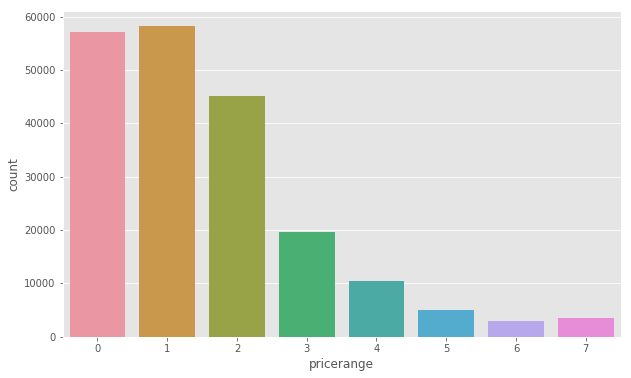

```python
plt.style.use('ggplot')
plt.figure(figsize=(10, 6))
sns.countplot(df_clean['pricerange'])
```

```python
# transfer categorical data to numerical data
ddc = df_clean.copy()

brand1 = pd.Series(range(39),index=ddc.brand.unique()).to_dict()
vt1 = pd.Series(range(8),index=ddc.vehicleType.unique()).to_dict()
gear1 = pd.Series(range(2),index=ddc.gearbox.unique()).to_dict()
fuel1 = pd.Series(range(7),index=ddc.fuelType.unique()).to_dict()
model1= pd.Series(range(248),index=ddc.model.unique()).to_dict()
nrd1 = pd.Series(range(3),index=ddc.notRepairedDamage.unique()).to_dict()

ddc['brand'] = ddc['brand'].map(brand1)
ddc['vehicleType'] = ddc['vehicleType'].map(vt1)
ddc['gearbox'] = ddc['gearbox'].map(gear1)
ddc['fuelType'] = ddc['fuelType'].map(fuel1)
ddc['model'] = ddc['model'].map(model1)
ddc['notRepairedDamage'] = ddc['notRepairedDamage'].map(nrd1)
```

```python
from sklearn.model_selection import train_test_split

X = ddc.drop(labels=["pricerange"], axis="columns")
y = ddc.pricerange.values
X_train, X_test, y_train, y_test = train_test_split(X, y, test_size=0.20, random_state=1)
label=list(set(y.astype(str)))
```

```python
y
```

```
array([2, 0, 1, ..., 2, 1, 6])
```

```python
from sklearn.preprocessing import StandardScaler
from sklearn.linear_model import LogisticRegression
from sklearn.pipeline import Pipeline
from sklearn.metrics import classification_report

pipe_lr = Pipeline([('scl', StandardScaler()),
                    ('clf', LogisticRegression(class_weight='balanced', random_state=1))])

pipe_lr.fit(X_train, y_train)
y_pred = pipe_lr.predict(X_test)
print(classification_report(y_test, y_pred, target_names=label))
```

```
              precision    recall  f1-score   support

           2       0.68      0.86      0.76     11428
           5       0.62      0.45      0.52     11694
           0       0.60      0.61      0.61      9117
           7       0.46      0.37      0.41      3827
           3       0.36      0.38      0.37      2097
           1       0.31      0.28      0.29      1013
           4       0.24      0.21      0.22       577
           6       0.23      0.51      0.32       670

   micro avg       0.58      0.58      0.58     40423
   macro avg       0.44      0.46      0.44     40423
weighted avg       0.58      0.58      0.58     40423
```

From the countplot shown above, it is clear that the numbers between each pricerange are unbalanced. Pricerange 1 has the most numbers and pricerange 6 has the least numbers. After comparing with different measure models, we decided to use F1 score. Because F1 score is good at evaluating uneven cases.

F1 scores has macro average and micro average methods. A macro-average will compute the metric independently for each class and then take the average (hence treating all classes equally), whereas a micro-average will aggregate the contributions of all classes to compute the average metric. For our case, it was apparently not equally distributed, so we chose the micro-average method. And from the classification report, we can see that the micro-average methods have higher precision than the macro-average method.

```python
from sklearn.metrics import make_scorer,f1_score

# use f1 micro as our scorer
scorer = make_scorer(score_func=f1_score,
                     pos_label=1,
                     greater_is_better=True,
                     average='micro')
```

## 1.5 Data Spliting Selection

Because there is significant imbalance in our dataset, stratified k-fold cross validation and stratified shuffle split both are good methods to split data. Stratified means each part preserves the same percentage of samples of each class as the original data. So we are considering about two methods: stratified k-fold and stratified shuffle split.

The stratified k-fold method shuffles data at first, and after that splits the data into n_splits folds and done. Every sample must be in one and only one fold. And it only and always shuffles data one time before splitting, therefore the test sets do not overlap. The stratified shuffle split method randomly samples the entire dataset during each iteration to generate a training set and a testing set. The test_size and train_size parameters control how large the testing and training set set should be for each iteration. Because the stratified shuffle split method shuffles each time before splitting and it splits n_splits times, the test sets can overlap, but it is also possible that some samples are neither in the training set nor the testing set.

As the dataset grows, the cross validation time increases. So, if the dataset is large, the shuffle split method might be better because we can tune the test_size and train_size parameters to take less time. After the data preparation, our dataset still contains 202112 records, which is not a small dataset, so we decide to use the shuffle split method.

### Stratified K-Fold

```python
from sklearn.model_selection import cross_val_score
from sklearn.model_selection import StratifiedKFold
```

```python
%%time
cv1 = StratifiedKFold(n_splits=10)
criteria1 = cross_val_score(estimator=pipe_lr,
                            X=X,
                            y=y,
                            cv=cv1,
                            scoring=scorer
                           )
```

```
Wall time: 1min 24s
```

```
[0.58367549 0.59018502 0.58424854 0.57799436 0.58690812 0.58690812
 0.58256222 0.58454154 0.5804137  0.58788599]
Mean: 0.584532309708695
```

```
(0.5679943600653045, 0.5901850202829722)
```

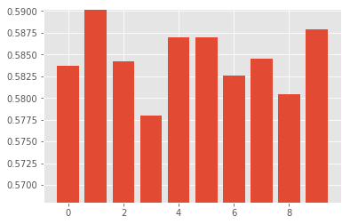

```python
print(criteria1)
print("Mean:", np.mean(criteria1))
plt.bar(range(len(criteria1)),criteria1)
plt.ylim([min(criteria1)-0.01,max(criteria1)])
```

### Stratified Shuffle split

```python
from sklearn.model_selection import StratifiedShuffleSplit
```

```python
%%time
cv2 = StratifiedShuffleSplit(train_size=0.5,test_size=0.2, n_splits=10)
criteria2 = cross_val_score(estimator=pipe_lr,
                            X=X,
                            y=y,
                            cv=cv2,
                            scoring=scorer
                           )
```

```
Wall time: 43.4 s
```

```
[0.5862504  0.58021423 0.58454345 0.5819954  0.58387552 0.58105534
 0.57959577 0.58152537 0.58345496 0.58726468]
Mean: 0.5829775128021175
```

```
(0.5695957746827301, 0.5872646760507632)
```

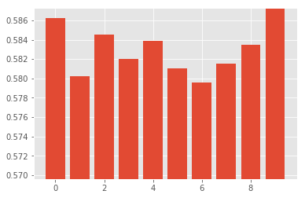

```python
print(criteria2)
print("Mean:", np.mean(criteria2))
plt.bar(range(len(criteria2)),criteria2)
plt.ylim([min(criteria2)-0.01,max(criteria2)])
```

When we set test_size=0.2 and train_size=0.5, the stratified shuffle split method took less time than the stratified k-fold method, but the F1 scores of two methods are similar.

# 2.Modeling

## 2.1 Create several combined wide and deep networks

```python
from sklearn.preprocessing import LabelEncoder
from sklearn.preprocessing import StandardScaler

#df = df_clean.copy()
# define objects that can encode each variable as integer
encoders = dict()
categorical_headers = ['vehicleType','gearbox','model',
                       'fuelType','brand','notRepairedDamage']
# train all encoders
for col in categorical_headers+['pricerange']:
    #df_train[col] = df_train[col].str.strip()
    #df_test[col] = df_test[col].str.strip()

    if col=="pricerange":
        tmp = LabelEncoder()
        df_clean[col] = tmp.fit_transform(df_clean[col])
       # df_test[col] = tmp.transform(df_test[col])
    else:
        # integer encoded variables
        encoders[col] = LabelEncoder() # save the encoder
        df_clean[col+'_int'] = encoders[col].fit_transform(df_clean[col])
        #df_test[col+'_int'] = encoders[col].transform(df_test[col])

# scale the numeric, continuous variables
numeric_headers = ["yearOfRegistration",'powerPS','kilometer','postalCode']

for col in numeric_headers:
    df_clean[col] = df_clean[col].astype(np.float)
    #df_test[col] = df_test[col].astype(np.float)

    ss = StandardScaler()
    df_clean[col] = ss.fit_transform(df_clean[col].values.reshape(-1, 1))
    #df_test[col] = ss.transform(df_test[col].values.reshape(-1, 1))

categorical_headers_ints = [x+'_int' for x in categorical_headers]
feature_columns = categorical_headers_ints+numeric_headers
```

```python
df_clean.head()
```

|  | vehicleType | yearOfRegistration | gearbox | powerPS | model | kilometer | fuelType | brand | notRepairedDamage | postalCode | pricerange | vehicleType_int | gearbox_int | model_int | fuelType_int | brand_int | notRepairedDamage_int |
| --- | --- | --- | --- | --- | --- | --- | --- | --- | --- | --- | --- | --- | --- | --- | --- | --- | --- |
| 2 | suv | 0.019416 | automatik | 0.535587 | grand | -0.003100 | diesel | jeep | not declare | 1.491472 | 2 | 7 | 0 | 118 | 3 | 14 | 2 |
| 3 | kleinwagen | -0.513694 | manuell | -0.965807 | golf | 0.648855 | benzin | volkswagen | nein | 1.514525 | 0 | 4 | 1 | 117 | 1 | 37 | 1 |
| 4 | kleinwagen | 0.730230 | manuell | -1.068175 | fabia | -0.915837 | diesel | skoda | nein | 0.325473 | 1 | 4 | 1 | 102 | 3 | 31 | 1 |
| 5 | limousine | -1.579915 | manuell | -0.505152 | 3er | 0.648855 | benzin | bmw | ja | -0.709306 | 0 | 6 | 1 | 11 | 1 | 2 | 0 |
| 6 | cabrio | 0.019416 | manuell | -0.385723 | 2_reihe | 0.648855 | benzin | peugeot | nein | 0.584536 | 1 | 2 | 1 | 8 | 1 | 25 | 1 |

```python
from sklearn import metrics as mt
from keras.layers import Dense, Activation, Input
from keras.layers import Embedding, Flatten, Concatenate
from keras.models import Model
```

### We select f1_score as the evaluation metric, since Precision, Recall and F1 metrics have been removed from metrics.py, so we try to calculate f1_score by using code. The code we used in the following cell are all from reference https://stackoverflow.com/questions/43547402/how-to-calculate-f1-macro-in-keras

```python
# we find f1 score calculation from https://stackoverflow.com/questions/43547402/how-to-calculate-f1-macro-in-keras
from sklearn.model_selection import StratifiedShuffleSplit
from keras import backend as K

def f1(y_true, y_pred):
    def recall(y_true, y_pred):
        true_positives = K.sum(K.round(K.clip(y_true * y_pred, 0, 1)))
        possible_positives = K.sum(K.round(K.clip(y_true, 0, 1)))
        recall = true_positives / (possible_positives + K.epsilon())
        return recall

    def precision(y_true, y_pred):
        true_positives = K.sum(K.round(K.clip(y_true * y_pred, 0, 1)))
        predicted_positives = K.sum(K.round(K.clip(y_pred, 0, 1)))
        precision = true_positives / (predicted_positives + K.epsilon())
        return precision
    precision = precision(y_true, y_pred)
    recall = recall(y_true, y_pred)
    return 2*((precision*recall)/(precision+recall+K.epsilon()))
```

```python
from sklearn.preprocessing import OneHotEncoder
X =  ss.fit_transform(df_clean[feature_columns].values).astype(np.float32)
y = df_clean['pricerange'].values.astype(np.int)
cv2 = StratifiedShuffleSplit(train_size=0.5,test_size=0.2, n_splits=10)
```

```
Train on 101056 samples, validate on 40423 samples
0.9324835519640787
Train on 101056 samples, validate on 40423 samples
0.9323458629782401
Train on 101056 samples, validate on 40423 samples
0.9332287017418812
Train on 101056 samples, validate on 40423 samples
0.9328440025764941
Train on 101056 samples, validate on 40423 samples
0.93381153088608
Train on 101056 samples, validate on 40423 samples
0.930936295593404
Train on 101056 samples, validate on 40423 samples
0.9328358970648546
Train on 101056 samples, validate on 40423 samples
0.9328795721720222
Train on 101056 samples, validate on 40423 samples
0.9313780795049071
Train on 101056 samples, validate on 40423 samples
0.9337886871596618
```

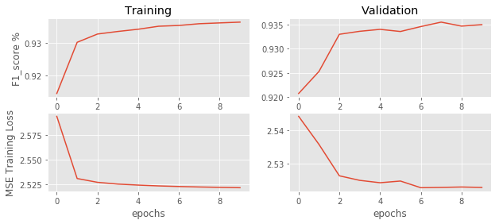

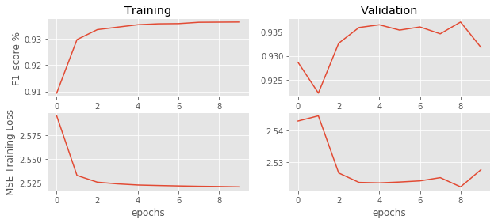

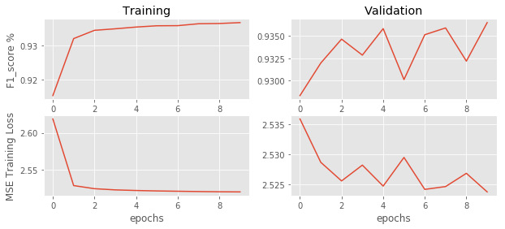

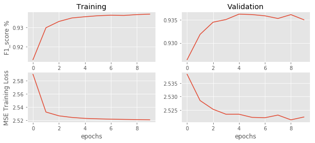

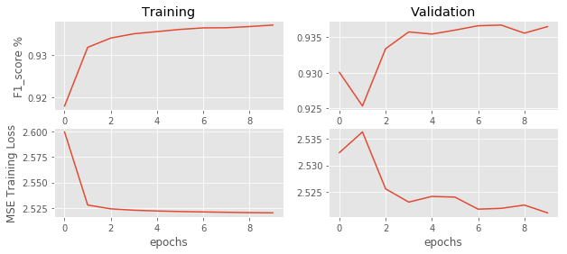

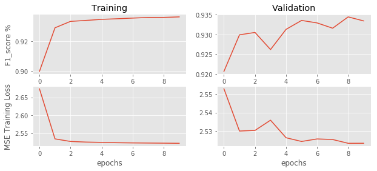

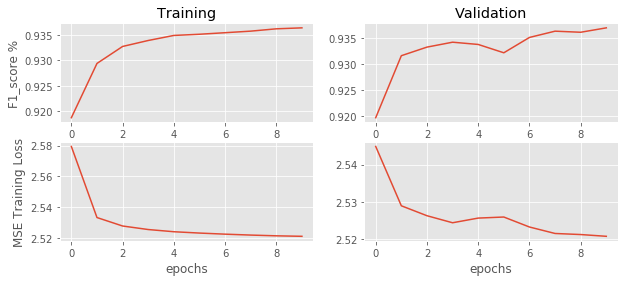

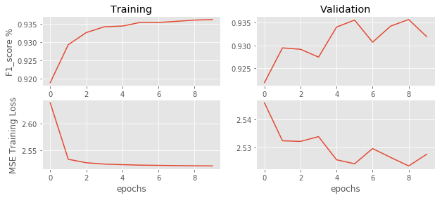

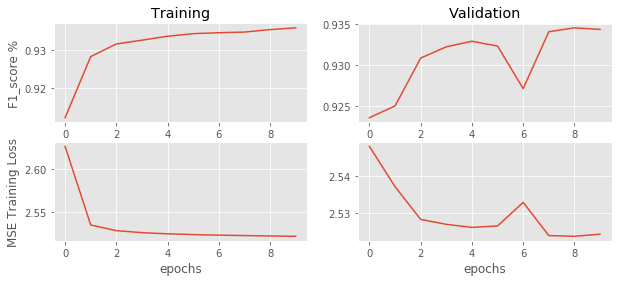

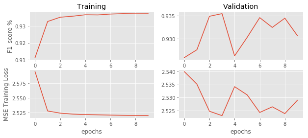

```python
acc = 0
for train_index, test_index in cv2.split(X, y):
    X_train, X_test= df_clean.iloc[train_index],df_clean.iloc[test_index]
    y_train, y_test= df_clean['pricerange'].iloc[train_index],df_clean['pricerange'].iloc[test_index]

    ohe = OneHotEncoder()
    X_train_ohe = ohe.fit_transform(X_train[categorical_headers_ints].values)
    X_test_ohe = ohe.transform(X_test[categorical_headers_ints].values)

    X_train_num =  X_train[numeric_headers].values
    X_test_num = X_test[numeric_headers].values

    from keras.layers import concatenate
    cross_columns = [['brand','model'],
                 ['brand','vehicleType'],
                 ['gearbox','model'],
                 ['fuelType','notRepairedDamage']]

# we need to create separate lists for each branch
    embed_branches = []
    X_ints_train = []
    X_ints_test = []
    all_inputs = []
    all_wide_branch_outputs = []

    for cols in cross_columns:
        # encode crossed columns as ints for the embedding
        enc = LabelEncoder()

        # create crossed labels
        X_crossed_train = X_train[cols].apply(lambda x: '_'.join(x), axis=1)
        X_crossed_test = X_test[cols].apply(lambda x: '_'.join(x), axis=1)

        enc.fit(np.hstack((X_crossed_train.values,  X_crossed_test.values)))
        X_crossed_train = enc.transform(X_crossed_train)
        X_crossed_test = enc.transform(X_crossed_test)
        X_ints_train.append( X_crossed_train )
        X_ints_test.append( X_crossed_test )

        # get the number of categories
        N = max(X_ints_train[-1]+1) # same as the max(df_train[col])

        # create embedding branch from the number of categories
        inputs = Input(shape=(1,),dtype='int32', name = '_'.join(cols))
        all_inputs.append(inputs)
        x = Embedding(input_dim=N,
                      output_dim=int(np.sqrt(N)),
                      input_length=1, name = '_'.join(cols)+'_embed')(inputs)
        x = Flatten()(x)
        all_wide_branch_outputs.append(x)

# merge the branches together
    wide_branch = concatenate(all_wide_branch_outputs, name='wide_concat')
    wide_branch = Dense(units=1,activation='sigmoid',name='wide_combined')(wide_branch)

    # reset this input branch
    all_deep_branch_outputs = []
    # add in the embeddings
    for col in categorical_headers_ints:
        # encode as ints for the embedding
        X_ints_train.append( X_train[col].values )
        X_ints_test.append( X_test[col].values )

        # get the number of categories
        N = max(X_ints_train[-1]+1) # same as the max(df_train[col])

        # create embedding branch from the number of categories
        inputs = Input(shape=(1,),dtype='int32', name=col)
        all_inputs.append(inputs)
        x = Embedding(input_dim=N,
                      output_dim=int(np.sqrt(N)),
                      input_length=1, name=col+'_embed')(inputs)
        x = Flatten()(x)
        all_deep_branch_outputs.append(x)

    # also get a dense branch of the numeric features
    all_inputs.append(Input(shape=(X_train_num.shape[1],),
                            sparse=False,
                            name='numeric_data'))

    x = Dense(units=20, activation='relu',name='numeric_1')(all_inputs[-1])
    all_deep_branch_outputs.append( x )

    # merge the deep branches together
    deep_branch = concatenate(all_deep_branch_outputs,name='concat_embeds')
    deep_branch = Dense(units=50,activation='relu', name='deep1')(deep_branch)
    deep_branch = Dense(units=25,activation='relu', name='deep2')(deep_branch)
    deep_branch = Dense(units=10,activation='relu', name='deep3')(deep_branch)

    final_branch = concatenate([wide_branch, deep_branch],name='concat_deep_wide')
    final_branch = Dense(units=1,activation='sigmoid',name='combined')(final_branch)

    model3 = Model(inputs=all_inputs, outputs=final_branch)


    model3.compile(optimizer='adagrad',
              loss='mean_squared_error',
              metrics=[f1])


# lets also add the history variable to see how we are doing
# and lets add a validation set to keep track of our progress
    history = model3.fit(X_ints_train+ [X_train_num],
                        y_train,
                        epochs=10,
                        batch_size=1000,
                        verbose=1,
                        validation_data = (X_ints_test + [X_test_num], y_test))

    a = np.sum(history.history['f1'])/10
    acc += a
    print(a)


    plt.figure(figsize=(10,4))
    plt.subplot(2,2,1)
    plt.plot(history.history['f1'])

    plt.ylabel('F1_score %')
    plt.title('Training')
    plt.subplot(2,2,2)
    plt.plot(history.history['val_f1'])
    plt.title('Validation')

    plt.subplot(2,2,3)
    plt.plot(history.history['loss'])
    plt.ylabel('MSE Training Loss')
    plt.xlabel('epochs')

    plt.subplot(2,2,4)
    plt.plot(history.history['val_loss'])
    plt.xlabel('epochs')
```

```python
acc_3_layer = acc/10
print(acc_3_layer)
```

```
0.9326532181641625
```

The average accuracy of f1_score is 0.9326532181641625.

```python
from IPython.display import SVG
from keras.utils.vis_utils import model_to_dot

SVG(model_to_dot(model3).create(prog='dot', format='svg'))
```

[figure not shown]

## 2.2 Altering the number of layers

We choose 4 and 7 layers to compare with the 3 layers we create in above

### 4 layers

```
Train on 101056 samples, validate on 40423 samples
0.9323109901469481
Train on 101056 samples, validate on 40423 samples
0.9348249077867715
Train on 101056 samples, validate on 40423 samples
0.9339706682933329
Train on 101056 samples, validate on 40423 samples
0.9337088206939829
Train on 101056 samples, validate on 40423 samples
0.9339204954347935
Train on 101056 samples, validate on 40423 samples
0.93297086696909
Train on 101056 samples, validate on 40423 samples
0.9336481231051845
Train on 101056 samples, validate on 40423 samples
0.9342815026890975
Train on 101056 samples, validate on 40423 samples
0.9331015330442641
Train on 101056 samples, validate on 40423 samples
0.9323956989370018
```

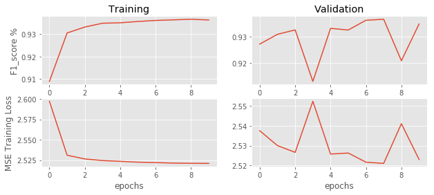

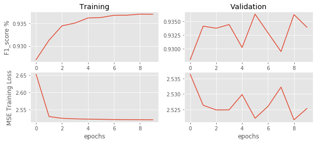

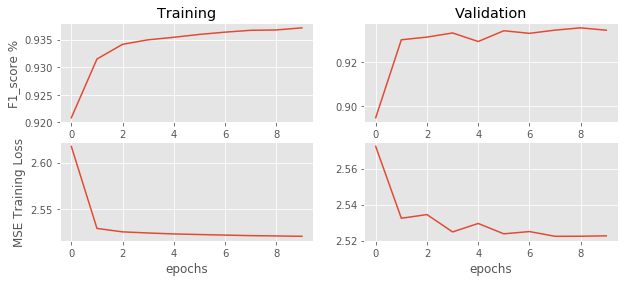

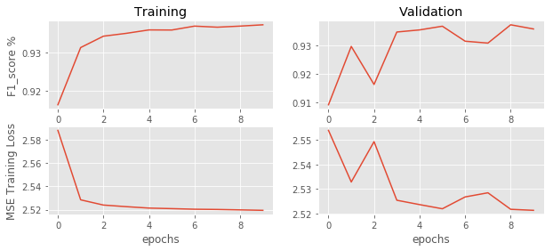

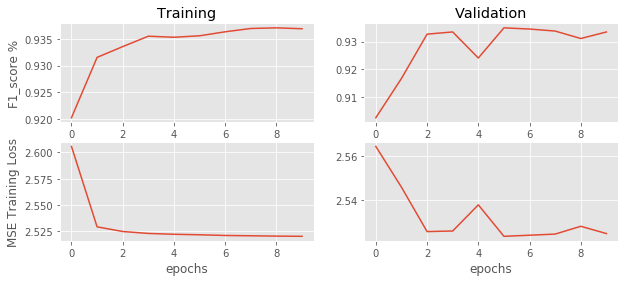

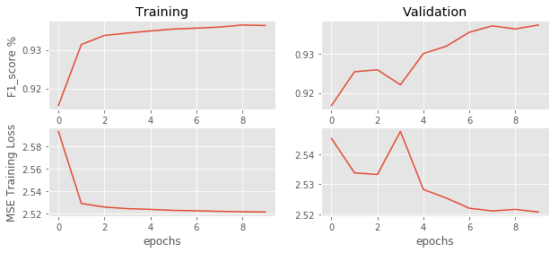

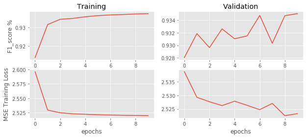

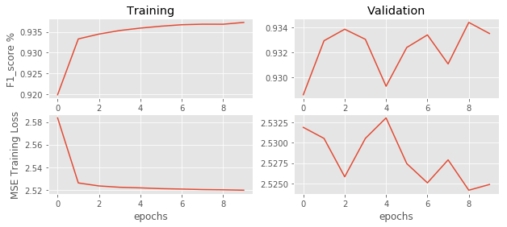

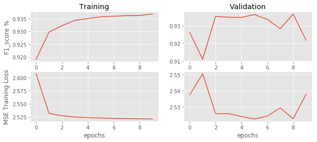

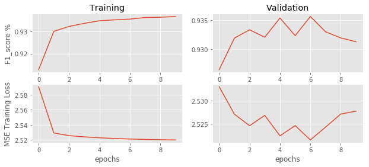

```python
acc4 = 0
for train_index, test_index in cv2.split(X, y):
    X_train, X_test= df_clean.iloc[train_index],df_clean.iloc[test_index]
    y_train, y_test= df_clean['pricerange'].iloc[train_index],df_clean['pricerange'].iloc[test_index]

    ohe = OneHotEncoder()
    X_train_ohe = ohe.fit_transform(X_train[categorical_headers_ints].values)
    X_test_ohe = ohe.transform(X_test[categorical_headers_ints].values)

    X_train_num =  X_train[numeric_headers].values
    X_test_num = X_test[numeric_headers].values

    from keras.layers import concatenate
    cross_columns = [['brand','model'],
                 ['brand','vehicleType'],
                 ['gearbox','model'],
                 ['fuelType','notRepairedDamage']]

# we need to create separate lists for each branch
    embed_branches = []
    X_ints_train = []
    X_ints_test = []
    all_inputs = []
    all_wide_branch_outputs = []

    for cols in cross_columns:
        # encode crossed columns as ints for the embedding
        enc = LabelEncoder()

        # create crossed labels
        X_crossed_train = X_train[cols].apply(lambda x: '_'.join(x), axis=1)
        X_crossed_test = X_test[cols].apply(lambda x: '_'.join(x), axis=1)

        enc.fit(np.hstack((X_crossed_train.values,  X_crossed_test.values)))
        X_crossed_train = enc.transform(X_crossed_train)
        X_crossed_test = enc.transform(X_crossed_test)
        X_ints_train.append( X_crossed_train )
        X_ints_test.append( X_crossed_test )

        # get the number of categories
        N = max(X_ints_train[-1]+1) # same as the max(df_train[col])

        # create embedding branch from the number of categories
        inputs = Input(shape=(1,),dtype='int32', name = '_'.join(cols))
        all_inputs.append(inputs)
        x = Embedding(input_dim=N,
                      output_dim=int(np.sqrt(N)),
                      input_length=1, name = '_'.join(cols)+'_embed')(inputs)
        x = Flatten()(x)
        all_wide_branch_outputs.append(x)

# merge the branches together
    wide_branch = concatenate(all_wide_branch_outputs, name='wide_concat')
    wide_branch = Dense(units=1,activation='sigmoid',name='wide_combined')(wide_branch)

    # reset this input branch
    all_deep_branch_outputs = []
    # add in the embeddings
    for col in categorical_headers_ints:
        # encode as ints for the embedding
        X_ints_train.append( X_train[col].values )
        X_ints_test.append( X_test[col].values )

        # get the number of categories
        N = max(X_ints_train[-1]+1) # same as the max(df_train[col])

        # create embedding branch from the number of categories
        inputs = Input(shape=(1,),dtype='int32', name=col)
        all_inputs.append(inputs)
        x = Embedding(input_dim=N,
                      output_dim=int(np.sqrt(N)),
                      input_length=1, name=col+'_embed')(inputs)
        x = Flatten()(x)
        all_deep_branch_outputs.append(x)

    # also get a dense branch of the numeric features
    all_inputs.append(Input(shape=(X_train_num.shape[1],),
                            sparse=False,
                            name='numeric_data'))

    x = Dense(units=20, activation='relu',name='numeric_1')(all_inputs[-1])
    all_deep_branch_outputs.append( x )

    # merge the deep branches together
    deep_branch = concatenate(all_deep_branch_outputs,name='concat_embeds')
    deep_branch = Dense(units=60,activation='relu', name='deep1')(deep_branch)
    deep_branch = Dense(units=50,activation='relu', name='deep2')(deep_branch)
    deep_branch = Dense(units=25,activation='relu', name='deep3')(deep_branch)
    deep_branch = Dense(units=10,activation='relu', name='deep4')(deep_branch)

    final_branch = concatenate([wide_branch, deep_branch],name='concat_deep_wide')
    final_branch = Dense(units=1,activation='sigmoid',name='combined')(final_branch)

    model4 = Model(inputs=all_inputs, outputs=final_branch)

    model4.compile(optimizer='adagrad',
              loss='mean_squared_error',
              metrics=[f1])

# lets also add the history variable to see how we are doing
# and lets add a validation set to keep track of our progress
    history = model4.fit(X_ints_train+ [X_train_num],
                    y_train,
                    epochs=10,
                    batch_size=1000,
                    verbose=1,
                    validation_data = (X_ints_test + [X_test_num], y_test))

    a = np.sum(history.history['f1'])/10
    acc4 += a
    print(a)


    plt.figure(figsize=(10,4))
    plt.subplot(2,2,1)
    plt.plot(history.history['f1'])

    plt.ylabel('F1_score %')
    plt.title('Training')
    plt.subplot(2,2,2)
    plt.plot(history.history['val_f1'])
    plt.title('Validation')

    plt.subplot(2,2,3)
    plt.plot(history.history['loss'])
    plt.ylabel('MSE Training Loss')
    plt.xlabel('epochs')

    plt.subplot(2,2,4)
    plt.plot(history.history['val_loss'])
    plt.xlabel('epochs')
```

```python
acc_4_layer = acc4/10
print(acc_4_layer)
```

```
0.9335133607100469
```

The average accuracy of f1_score is 0.9335133607100469

```python
from IPython.display import SVG
from keras.utils.vis_utils import model_to_dot

SVG(model_to_dot(model4).create(prog='dot', format='svg'))
```

[figure not shown]